# Single-locus validation of the BC2S3 simulation

- Show All Code
- Hide All Code
- View Source

Does the simcross BC2S3 simulator reproduce the breeding-scheme genotype frequencies? — on the TeoNAM native v5 map

Author

Fausto Rodríguez-Zapata

Published

July 10, 2026

Does the Broman/`simcross` BC2S3 simulation reproduce the **single-locus breeding-scheme expectation** for the REF/Het/ALT genome fractions? This notebook runs that check on the **TeoNAM native v5 cM map** (the same 118K-marker grid the per-coverage caller calibration uses), validating the simulator this repo’s coverage-degradation sweeps rely on. It is a *circularity* check: before trusting a caller’s recovery of the truth, confirm the truth-generator itself is unbiased.

The sim stack is zealhmm’s own (`R/simulate.R`: `.bcsft_pedigree`, `.simulate_dosage`); the single-locus expectation and the design-correct goodness-of-fit test are in `R/single_locus.R` (ported from the exploratory `zealtiger` repo). Why Hotelling and not Pearson, why Mb on real marker coordinates, and the ergodicity distinction are explained inline.

## Setup

```r
suppressMessages({
  library(data.table)
  library(dplyr)
  library(ggplot2)
  library(simcross)
  library(patchwork)
  library(here)
})
source(here("R/simulate.R")) # .bcsft_pedigree, .chr_cm_lengths, .simulate_dosage
source(here("R/single_locus.R")) # single_locus_p0, state_fractions_mb, hotelling_fractions, plot_fraction_forest
set.seed(params$seed)

# TeoNAM native v5 cM map — the 118K-marker grid used by the caller calibration.
mc <- fread(here("data/teonam/markers_v5_gwas118k_cm.tsv"))
map <- mc[, .(chr = as.integer(chr), bp = as.integer(pos_v5), cm = as.numeric(cm))][order(chr, bp)]
markers <- map # the native markers directly carry chr/bp/cm — no re-gridding

bp <- .bcsft_pedigree(n_bc = 2L, n_self = 3L)
ped <- bp$ped
nid <- bp$nil_id
cmlen <- .chr_cm_lengths(map)
cat(sprintf(
  "simcross %s | native markers: %d | genome: %.0f cM | N: %d\n",
  as.character(packageVersion("simcross")), nrow(markers), sum(cmlen$L), params$n
))
```

```
simcross 0.8 | native markers: 118514 | genome: 1559 cM | N: 1500
```

## 1. The single-locus expectation (BC2S3 transition matrix)

The genotype distribution at any single locus after F1 → 2 backcrosses → 3 selfings, from the breeding-scheme transition matrices (map- and interference-independent — a marginal quantity).

```r
p0 <- single_locus_p0(n_bc = 2L, n_self = 3L)
tibble(state = names(p0), expected = as.numeric(p0)) |>
  mutate(note = c("hom recurrent", "het", "hom donor")) |>
  knitr::kable(digits = 6)
```

| state | expected | note |
| --- | --- | --- |
| REF | 0.859375 | hom recurrent |
| Het | 0.031250 | het |
| ALT | 0.109375 | hom donor |

```r
cat(sprintf(
  "donor dosage = ALT + 0.5*Het = %.4f (expect 0.1250)\n",
  p0["ALT"] + 0.5 * p0["Het"]
))
```

```
donor dosage = ALT + 0.5*Het = 0.1250 (expect 0.1250)
```

## 2. f_i validation (Mb-based, Hotelling)

Simulate `n` NILs on the native map, tabulate per-NIL Mb fractions, and test the population means against `p0` with the design-correct Hotelling/Wald χ²(2) (sample = unit; empirical between-sample covariance — **not** per-marker binomial, which linkage overdispersion would make reject a correct sampler).

```r
F <- t(vapply(seq_len(params$n), function(i) {
  state_fractions_mb(markers, .simulate_dosage(ped, cmlen, markers,
    m = params$m, p = params$p, nil_id = nid
  ))
}, numeric(3)))
colnames(F) <- c("REF", "Het", "ALT")
res <- hotelling_fractions(F, p0)
knitr::kable(res$table, digits = 5)
```

| state | expected | estimate | se | ci_lo | ci_hi | sd_fi | in_ci |
| --- | --- | --- | --- | --- | --- | --- | --- |
| REF | 0.85938 | 0.86050 | 0.00189 | 0.85680 | 0.86420 | 0.07309 | TRUE |
| Het | 0.03125 | 0.03078 | 0.00081 | 0.02919 | 0.03237 | 0.03146 | TRUE |
| ALT | 0.10938 | 0.10872 | 0.00168 | 0.10544 | 0.11201 | 0.06488 | TRUE |

```r
cat(sprintf(
  "Hotelling T^2 = %.3f (df=2), chi2 p = %.4g | N_eff(ALT) = %.1f vs %d markers\n",
  res$T2, res$p_chisq,
  with(res$table[res$table$state == "ALT", ], expected * (1 - expected) / sd_fi^2),
  nrow(markers)
))
```

```
Hotelling T^2 = 0.474 (df=2), chi2 p = 0.7891 | N_eff(ALT) = 23.1 vs 118514 markers
```

```r
cat(if (all(res$table$in_ci)) {
  "PASS: all expectations inside 95% Wald CIs.\n"
} else {
  "CHECK: an expectation outside its CI.\n"
})
```

```
PASS: all expectations inside 95% Wald CIs.
```

The fractions span ~2 orders of magnitude, so a single linear forest plot can show magnitude *or* intervals but not both. Panel **A** (log axis) carries magnitude; panel **B** (standardized deviation, ±1.96 band) carries the pass criterion — scale-free.

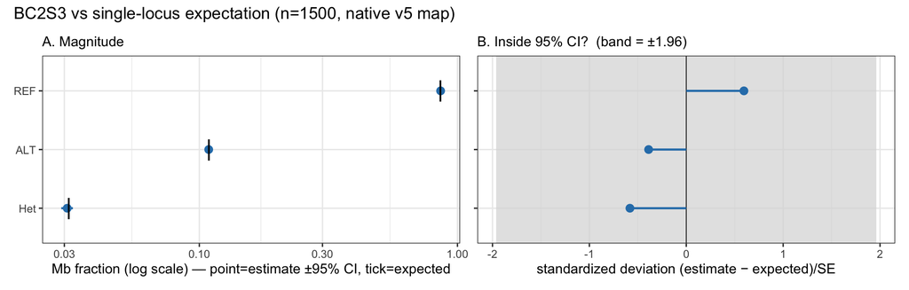

```r
plot_fraction_forest(res$table,
  title = sprintf(
    "BC2S3 vs single-locus expectation (n=%d, native v5 map)",
    params$n
  )
)
```

`N_eff` (not the marker count) is the ergodicity-limited effective sample size: with ~33 crossovers/genome the per-NIL fraction averages over few independent blocks, so the right SE is `sd(f_i)/√N`, not a per-marker binomial. This is the same ergodicity distinction developed in the wideseq coverage-ergodicity note.

## 3. Marker-resolution sweep

The fractions above are measured on the full native grid. How does the **Het** fraction degrade as the grid coarsens? Short Het tracts that fall below the marker spacing are missed — a truth-*measurement* floor, distinct from the low-coverage Het *miscalling* an ancestry caller faces (layer 2). We simulate one set of NILs **once** and re-measure each on grids of increasing density (built by `build_marker_grid`), reporting Cohen’s $d=(\text{mean}-\text{expected})/\text{SD}$ of the Het fraction — an N-independent effect size, negative when Het is undercounted.

```r
set.seed(params$seed + 1L)
n_sweep <- min(params$n, 800L)
# simulate the shared meiosis once per NIL, then read dosage on any grid
sims <- lapply(seq_len(n_sweep), function(i) {
  simcross::sim_from_pedigree(ped, L = cmlen$L, m = params$m, p = params$p)
})
dosage_from_sim <- function(sim, mk) {
  d <- integer(nrow(mk))
  for (ci in seq_len(nrow(cmlen))) {
    rows <- which(mk$chr == cmlen$chr[ci])
    if (!length(rows)) next
    nil <- sim[[ci]][[nid]]
    cm <- mk$cm[rows]
    d[rows] <- (.hap_allele_at(nil$mat, cm) == 2L) + (.hap_allele_at(nil$pat, cm) == 2L)
  }
  d
}
dens <- c(500L, 1000L, 2000L, 4000L, 8000L, 16000L)
sw <- rbindlist(lapply(dens, function(D) {
  mk <- build_marker_grid(map, n_markers = D)
  het <- vapply(sims, function(s) state_fractions_mb(mk, dosage_from_sim(s, mk))[["Het"]], numeric(1))
  gap <- mk[, as.double(stats::median(diff(sort(bp)))), by = chr][, stats::median(V1)]
  data.table(
    markers = nrow(mk), spacing_Mb = round(gap / 1e6, 3),
    Het_mean = round(mean(het), 4),
    Het_d = round((mean(het) - p0[["Het"]]) / stats::sd(het), 3)
  )
}))
knitr::kable(sw, caption = sprintf(
  "Het fraction vs marker density (same %d NILs re-measured on each grid; expected Het = %.4f). Cohen's d = (mean - expected)/SD.",
  n_sweep, p0[["Het"]]
))
```

Het fraction vs marker density (same 800 NILs re-measured on each grid; expected Het = 0.0312). Cohen’s d = (mean - expected)/SD.

| markers | spacing_Mb | Het_mean | Het_d |
| --- | --- | --- | --- |
| 500 | 4.333 | 0.0258 | -0.177 |
| 1001 | 2.137 | 0.0280 | -0.103 |
| 2000 | 1.063 | 0.0294 | -0.061 |
| 4000 | 0.531 | 0.0301 | -0.037 |
| 8000 | 0.265 | 0.0305 | -0.024 |
| 16000 | 0.132 | 0.0307 | -0.018 |

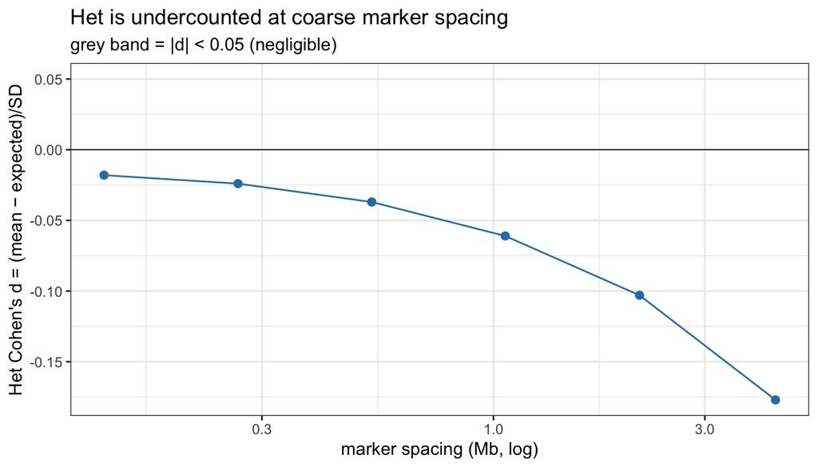

```r
ggplot(sw, aes(spacing_Mb, Het_d)) +
  annotate("rect", xmin = -Inf, xmax = Inf, ymin = -0.05, ymax = 0.05, fill = "grey90") +
  geom_hline(yintercept = 0, linewidth = 0.3) +
  geom_line(colour = "#2c7fb8") +
  geom_point(colour = "#2c7fb8", size = 2) +
  scale_x_log10() +
  labs(
    x = "marker spacing (Mb, log)", y = "Het Cohen's d = (mean − expected)/SD",
    title = "Het is undercounted at coarse marker spacing",
    subtitle = "grey band = |d| < 0.05 (negligible)"
  ) +
  theme_bw()
```

**Reading it:** Het is undercounted ($d<0$) at coarse spacing — small Het segments fall below the marker resolution and are lost — and relaxes to a negligible residual ($|d|<0.05$) as the grid densifies. This is a truth-*measurement* floor, not a caller artifact; the layer-1 validation (§1–§2) does not depend on it.

## Conclusion

On the TeoNAM native v5 map, the `simcross` BC2S3 simulator reproduces the single-locus genotype fractions — all three states inside their 95% CIs, donor dosage 0.125 — so the truth-generator behind the coverage-degradation sweeps is unbiased at the single-locus margin. The only known deviation is a marker-resolution undercount of Het at coarse spacing (§3, negligible below ~0.5 Mb). Layer 1 (truth) is validated; caller observation/recovery under coverage is the calibration and sweep notebooks.